# FIFA 2019 player analysis

### About the data:-

data.csv includes lastest edition FIFA 2019 players attributes like Age, Nationality, Overall, Potential, Club, Value, Wage, Preferred Foot, International Reputation, Weak Foot, Skill Moves, Work Rate, Position, Jersey Number, Joined, Loaned From, Contract Valid Until, Height, Weight, LS, ST, RS, LW, LF, CF, RF, RW, LAM, CAM, RAM, LM, LCM, CM, RCM, RM, LWB, LDM, CDM, RDM, RWB, LB, LCB, CB, RCB, RB, Crossing, Finishing, Heading, Accuracy, ShortPassing, Volleys, Dribbling, Curve, FKAccuracy, LongPassing, BallControl, Acceleration, SprintSpeed, Agility, Reactions, Balance, ShotPower, Jumping, Stamina, Strength, LongShots, Aggression, Interceptions, Positioning, Vision, Penalties, Composure, Marking, StandingTackle, SlidingTackle, GKDiving, GKHandling, GKKicking, GKPositioning, GKReflexes, and Release Clause.

```python
import pandas as pd
import numpy as np
import seaborn as sns
import matplotlib.pyplot as plt
%matplotlib inline

from plotly.offline import iplot
import plotly as py
import plotly.tools as tls

import cufflinks as cf

import plotly.express as px
import pandas_profiling as pf
py.offline.init_notebook_mode(connected=True)
cf.go_offline()
```

```python
df = pd.read_csv("FIFA_data.csv")
```

```python
df.loc[0]
```

```
Unnamed: 0                                                     0
ID                                                        158023
Name                                                    L. Messi
Age                                                           31
Photo             https://cdn.sofifa.org/players/4/19/158023.png
                                       ...
GKHandling                                                  11.0
GKKicking                                                   15.0
GKPositioning                                               14.0
GKReflexes                                                   8.0
Release Clause                                           €226.5M
Name: 0, Length: 89, dtype: object
```

```python
df.columns
```

```
Index(['Unnamed: 0', 'ID', 'Name', 'Age', 'Photo', 'Nationality', 'Flag',
       'Overall', 'Potential', 'Club', 'Club Logo', 'Value', 'Wage', 'Special',
       'Preferred Foot', 'International Reputation', 'Weak Foot',
       'Skill Moves', 'Work Rate', 'Body Type', 'Real Face', 'Position',
       'Jersey Number', 'Joined', 'Loaned From', 'Contract Valid Until',
       'Height', 'Weight', 'LS', 'ST', 'RS', 'LW', 'LF', 'CF', 'RF', 'RW',
       'LAM', 'CAM', 'RAM', 'LM', 'LCM', 'CM', 'RCM', 'RM', 'LWB', 'LDM',
       'CDM', 'RDM', 'RWB', 'LB', 'LCB', 'CB', 'RCB', 'RB', 'Crossing',
       'Finishing', 'HeadingAccuracy', 'ShortPassing', 'Volleys', 'Dribbling',
       'Curve', 'FKAccuracy', 'LongPassing', 'BallControl', 'Acceleration',
       'SprintSpeed', 'Agility', 'Reactions', 'Balance', 'ShotPower',
       'Jumping', 'Stamina', 'Strength', 'LongShots', 'Aggression',
       'Interceptions', 'Positioning', 'Vision', 'Penalties', 'Composure',
       'Marking', 'StandingTackle', 'SlidingTackle', 'GKDiving', 'GKHandling',
       'GKKicking', 'GKPositioning', 'GKReflexes', 'Release Clause'],
      dtype='object')
```

```python
df.info()
```

```
<class 'pandas.core.frame.DataFrame'>
RangeIndex: 18207 entries, 0 to 18206
Data columns (total 89 columns):
 #   Column                    Non-Null Count  Dtype
---  ------                    --------------  -----
 0   Unnamed: 0                18207 non-null  int64
 1   ID                        18207 non-null  int64
 2   Name                      18207 non-null  object
 3   Age                       18207 non-null  int64
 4   Photo                     18207 non-null  object
 5   Nationality               18207 non-null  object
 6   Flag                      18207 non-null  object
 7   Overall                   18207 non-null  int64
 8   Potential                 18207 non-null  int64
 9   Club                      17966 non-null  object
```

[output cut: 81 more lines]

### Since there are many unnecessary columns

- We will drop that columns

```python
df.drop(columns = ['Unnamed: 0', 'ID', 'Photo', 'Flag', 'Club Logo', 'Loaned From'], axis=1, inplace=True)
```

```python
df
```

|  | Name | Age | Nationality | Overall | Potential | Club | Value | Wage | Special | Preferred Foot | ... | Composure | Marking | StandingTackle | SlidingTackle | GKDiving | GKHandling | GKKicking | GKPositioning | GKReflexes | Release Clause |
| --- | --- | --- | --- | --- | --- | --- | --- | --- | --- | --- | --- | --- | --- | --- | --- | --- | --- | --- | --- | --- | --- |
| 0 | L. Messi | 31 | Argentina | 94 | 94 | FC Barcelona | €110.5M | €565K | 2202 | Left | ... | 96.0 | 33.0 | 28.0 | 26.0 | 6.0 | 11.0 | 15.0 | 14.0 | 8.0 | €226.5M |
| 1 | Cristiano Ronaldo | 33 | Portugal | 94 | 94 | Juventus | €77M | €405K | 2228 | Right | ... | 95.0 | 28.0 | 31.0 | 23.0 | 7.0 | 11.0 | 15.0 | 14.0 | 11.0 | €127.1M |
| 2 | Neymar Jr | 26 | Brazil | 92 | 93 | Paris Saint-Germain | €118.5M | €290K | 2143 | Right | ... | 94.0 | 27.0 | 24.0 | 33.0 | 9.0 | 9.0 | 15.0 | 15.0 | 11.0 | €228.1M |
| 3 | De Gea | 27 | Spain | 91 | 93 | Manchester United | €72M | €260K | 1471 | Right | ... | 68.0 | 15.0 | 21.0 | 13.0 | 90.0 | 85.0 | 87.0 | 88.0 | 94.0 | €138.6M |
| 4 | K. De Bruyne | 27 | Belgium | 91 | 92 | Manchester City | €102M | €355K | 2281 | Right | ... | 88.0 | 68.0 | 58.0 | 51.0 | 15.0 | 13.0 | 5.0 | 10.0 | 13.0 | €196.4M |
| ... | ... | ... | ... | ... | ... | ... | ... | ... | ... | ... | ... | ... | ... | ... | ... | ... | ... | ... | ... | ... | ... |
| 18202 | J. Lundstram | 19 | England | 47 | 65 | Crewe Alexandra | €60K | €1K | 1307 | Right | ... | 45.0 | 40.0 | 48.0 | 47.0 | 10.0 | 13.0 | 7.0 | 8.0 | 9.0 | €143K |
| 18203 | N. Christoffersson | 19 | Sweden | 47 | 63 | Trelleborgs FF | €60K | €1K | 1098 | Right | ... | 42.0 | 22.0 | 15.0 | 19.0 | 10.0 | 9.0 | 9.0 | 5.0 | 12.0 | €113K |
| 18204 | B. Worman | 16 | England | 47 | 67 | Cambridge United | €60K | €1K | 1189 | Right | ... | 41.0 | 32.0 | 13.0 | 11.0 | 6.0 | 5.0 | 10.0 | 6.0 | 13.0 | €165K |
| 18205 | D. Walker-Rice | 17 | England | 47 | 66 | Tranmere Rovers | €60K | €1K | 1228 | Right | ... | 46.0 | 20.0 | 25.0 | 27.0 | 14.0 | 6.0 | 14.0 | 8.0 | 9.0 | €143K |
| 18206 | G. Nugent | 16 | England | 46 | 66 | Tranmere Rovers | €60K | €1K | 1321 | Right | ... | 43.0 | 40.0 | 43.0 | 50.0 | 10.0 | 15.0 | 9.0 | 12.0 | 9.0 | €165K |

18207 rows × 83 columns

## Performing the data cleaning

1. Cleaning the euro values from Value, Wage and Release Clause
2. Rating the Work Rate in terms of numeric values

```python
df.columns
```

```
Index(['Name', 'Age', 'Nationality', 'Overall', 'Potential', 'Club', 'Value',
       'Wage', 'Special', 'Preferred Foot', 'International Reputation',
       'Weak Foot', 'Skill Moves', 'Work Rate', 'Body Type', 'Real Face',
       'Position', 'Jersey Number', 'Joined', 'Contract Valid Until', 'Height',
       'Weight', 'LS', 'ST', 'RS', 'LW', 'LF', 'CF', 'RF', 'RW', 'LAM', 'CAM',
       'RAM', 'LM', 'LCM', 'CM', 'RCM', 'RM', 'LWB', 'LDM', 'CDM', 'RDM',
       'RWB', 'LB', 'LCB', 'CB', 'RCB', 'RB', 'Crossing', 'Finishing',
       'HeadingAccuracy', 'ShortPassing', 'Volleys', 'Dribbling', 'Curve',
       'FKAccuracy', 'LongPassing', 'BallControl', 'Acceleration',
       'SprintSpeed', 'Agility', 'Reactions', 'Balance', 'ShotPower',
       'Jumping', 'Stamina', 'Strength', 'LongShots', 'Aggression',
       'Interceptions', 'Positioning', 'Vision', 'Penalties', 'Composure',
       'Marking', 'StandingTackle', 'SlidingTackle', 'GKDiving', 'GKHandling',
       'GKKicking', 'GKPositioning', 'GKReflexes', 'Release Clause'],
      dtype='object')
```

```python
df['Work Rate'].unique()
```

```
array(['Medium/ Medium', 'High/ Low', 'High/ Medium', 'High/ High',
       'Medium/ High', 'Medium/ Low', 'Low/ High', 'Low/ Medium',
       'Low/ Low', nan], dtype=object)
```

```python
work_rate_dict = {'Medium/ Medium': 6,'High/ Low':8 ,'High/ Medium':9 ,'High/ High':10 ,'Medium/ High':7 ,'Medium/ Low':5 ,'Low/ High':4, 'Low/ Medium':3 ,'Low/ Low':2 }
```

```python
def euro_clean(x):
    if type(x) is float:
        return np.NaN

    x = x[1::]
    if x[-1] == 'K':  x = float(x[:-1])*1000
    elif x[-1] == 'M': x = float(x[:-1])*1000000
    else: x = np.NaN
    return x


def work_rate_clean(x):
    if type(x) is float:
        return np.NaN
    return work_rate_dict[x]

def height_to_cm(x):
    if type(x) is float:
        return np.NaN
    x,y = x.split('\'')
    x = x+"."+y
    x = float(x)*2.54
    return round(x,2)

def weight_clean(x):
    if type(x) is float:
        return np.NaN
    return x[:-3]

def experience(x,y):
    if type(x) is float:
        return np.NaN
    elif type(y) is float:
        y = 2022
    x = x[-4::]
    print(x,y)
    z = int(y) - int(x)
    return z

value_li = []
wage_li = []
release_li = []
work_rate_li = []
height_li = []
weight_li = []
experience_li = []

for i in range(df.shape[0]):
    value_li.append(euro_clean(df.iloc[i,6]))
    wage_li.append(euro_clean(df.iloc[i,7]))
    release_li.append(euro_clean(df.iloc[i,-1]))
    work_rate_li.append(work_rate_clean(df.iloc[i,13]))
    height_li.append(height_to_cm(df.iloc[i,20]))
    weight_li.append(weight_clean(df.iloc[i,21]))
    experience_li.append(experience(df.iloc[i,18], df.iloc[i,19]))
```

```python
df.iloc[:,6] = value_li
df.iloc[:,7] = wage_li
df.iloc[:,-1] = release_li
df.iloc[:.13] = work_rate_li
df.iloc[:,20] = height_li
df.iloc[:,21] = weight_li
```

```python
df['Experience'] = experience_li
df.drop(columns = ['Joined','Contract Valid Until'],axis=1,inplace=True)
```

```python
df
```

|  | Name | Age | Nationality | Overall | Potential | Club | Value | Wage | Special | Preferred Foot | ... | Marking | StandingTackle | SlidingTackle | GKDiving | GKHandling | GKKicking | GKPositioning | GKReflexes | Release Clause | Experience |
| --- | --- | --- | --- | --- | --- | --- | --- | --- | --- | --- | --- | --- | --- | --- | --- | --- | --- | --- | --- | --- | --- |
| 0 | L. Messi | 31 | Argentina | 94 | 94 | FC Barcelona | 110500000.0 | 565000.0 | 2202 | Left | ... | 33.0 | 28.0 | 26.0 | 6.0 | 11.0 | 15.0 | 14.0 | 8.0 | 226500000.0 | 17.0 |
| 1 | Cristiano Ronaldo | 33 | Portugal | 94 | 94 | Juventus | 77000000.0 | 405000.0 | 2228 | Right | ... | 28.0 | 31.0 | 23.0 | 7.0 | 11.0 | 15.0 | 14.0 | 11.0 | 127100000.0 | 4.0 |
| 2 | Neymar Jr | 26 | Brazil | 92 | 93 | Paris Saint-Germain | 118500000.0 | 290000.0 | 2143 | Right | ... | 27.0 | 24.0 | 33.0 | 9.0 | 9.0 | 15.0 | 15.0 | 11.0 | 228100000.0 | 5.0 |
| 3 | De Gea | 27 | Spain | 91 | 93 | Manchester United | 72000000.0 | 260000.0 | 1471 | Right | ... | 15.0 | 21.0 | 13.0 | 90.0 | 85.0 | 87.0 | 88.0 | 94.0 | 138600000.0 | 9.0 |
| 4 | K. De Bruyne | 27 | Belgium | 91 | 92 | Manchester City | 102000000.0 | 355000.0 | 2281 | Right | ... | 68.0 | 58.0 | 51.0 | 15.0 | 13.0 | 5.0 | 10.0 | 13.0 | 196400000.0 | 8.0 |
| ... | ... | ... | ... | ... | ... | ... | ... | ... | ... | ... | ... | ... | ... | ... | ... | ... | ... | ... | ... | ... | ... |
| 18202 | J. Lundstram | 19 | England | 47 | 65 | Crewe Alexandra | 60000.0 | 1000.0 | 1307 | Right | ... | 40.0 | 48.0 | 47.0 | 10.0 | 13.0 | 7.0 | 8.0 | 9.0 | 143000.0 | 2.0 |
| 18203 | N. Christoffersson | 19 | Sweden | 47 | 63 | Trelleborgs FF | 60000.0 | 1000.0 | 1098 | Right | ... | 22.0 | 15.0 | 19.0 | 10.0 | 9.0 | 9.0 | 5.0 | 12.0 | 113000.0 | 2.0 |
| 18204 | B. Worman | 16 | England | 47 | 67 | Cambridge United | 60000.0 | 1000.0 | 1189 | Right | ... | 32.0 | 13.0 | 11.0 | 6.0 | 5.0 | 10.0 | 6.0 | 13.0 | 165000.0 | 4.0 |
| 18205 | D. Walker-Rice | 17 | England | 47 | 66 | Tranmere Rovers | 60000.0 | 1000.0 | 1228 | Right | ... | 20.0 | 25.0 | 27.0 | 14.0 | 6.0 | 14.0 | 8.0 | 9.0 | 143000.0 | 1.0 |
| 18206 | G. Nugent | 16 | England | 46 | 66 | Tranmere Rovers | 60000.0 | 1000.0 | 1321 | Right | ... | 40.0 | 43.0 | 50.0 | 10.0 | 15.0 | 9.0 | 12.0 | 9.0 | 165000.0 | 1.0 |

18207 rows × 82 columns

```python
input()
```

```
''
```

## Passing into pandas profiler

```python
profile = pf.ProfileReport(df=df,minimal=True,explorative=False)
profile.to_file(output_file="Profiling_report.html")
```

```python
df.iloc[::,70::]
```

|  | Penalties | Composure | Marking | StandingTackle | SlidingTackle | GKDiving | GKHandling | GKKicking | GKPositioning | GKReflexes | Release Clause | Experience |
| --- | --- | --- | --- | --- | --- | --- | --- | --- | --- | --- | --- | --- |
| 0 | 75.0 | 96.0 | 33.0 | 28.0 | 26.0 | 6.0 | 11.0 | 15.0 | 14.0 | 8.0 | 226500000.0 | 17.0 |
| 1 | 85.0 | 95.0 | 28.0 | 31.0 | 23.0 | 7.0 | 11.0 | 15.0 | 14.0 | 11.0 | 127100000.0 | 4.0 |
| 2 | 81.0 | 94.0 | 27.0 | 24.0 | 33.0 | 9.0 | 9.0 | 15.0 | 15.0 | 11.0 | 228100000.0 | 5.0 |
| 3 | 40.0 | 68.0 | 15.0 | 21.0 | 13.0 | 90.0 | 85.0 | 87.0 | 88.0 | 94.0 | 138600000.0 | 9.0 |
| 4 | 79.0 | 88.0 | 68.0 | 58.0 | 51.0 | 15.0 | 13.0 | 5.0 | 10.0 | 13.0 | 196400000.0 | 8.0 |
| ... | ... | ... | ... | ... | ... | ... | ... | ... | ... | ... | ... | ... |
| 18202 | 43.0 | 45.0 | 40.0 | 48.0 | 47.0 | 10.0 | 13.0 | 7.0 | 8.0 | 9.0 | 143000.0 | 2.0 |
| 18203 | 43.0 | 42.0 | 22.0 | 15.0 | 19.0 | 10.0 | 9.0 | 9.0 | 5.0 | 12.0 | 113000.0 | 2.0 |
| 18204 | 55.0 | 41.0 | 32.0 | 13.0 | 11.0 | 6.0 | 5.0 | 10.0 | 6.0 | 13.0 | 165000.0 | 4.0 |
| 18205 | 50.0 | 46.0 | 20.0 | 25.0 | 27.0 | 14.0 | 6.0 | 14.0 | 8.0 | 9.0 | 143000.0 | 1.0 |
| 18206 | 33.0 | 43.0 | 40.0 | 43.0 | 50.0 | 10.0 | 15.0 | 9.0 | 12.0 | 9.0 | 165000.0 | 1.0 |

18207 rows × 12 columns

```python
df['Height']
```

```
0        14.48
1        15.75
2        14.99
3        16.26
4        12.98
         ...
18202    14.99
18203    16.00
18204    14.73
18205    12.95
18206    12.95
Name: Height, Length: 18207, dtype: float64
```

```python
df.columns
```

```
Index(['Name', 'Age', 'Nationality', 'Overall', 'Potential', 'Club', 'Value',
       'Wage', 'Special', 'Preferred Foot', 'International Reputation',
       'Weak Foot', 'Skill Moves', 'Work Rate', 'Body Type', 'Real Face',
       'Position', 'Jersey Number', 'Height', 'Weight', 'LS', 'ST', 'RS', 'LW',
       'LF', 'CF', 'RF', 'RW', 'LAM', 'CAM', 'RAM', 'LM', 'LCM', 'CM', 'RCM',
       'RM', 'LWB', 'LDM', 'CDM', 'RDM', 'RWB', 'LB', 'LCB', 'CB', 'RCB', 'RB',
       'Crossing', 'Finishing', 'HeadingAccuracy', 'ShortPassing', 'Volleys',
       'Dribbling', 'Curve', 'FKAccuracy', 'LongPassing', 'BallControl',
       'Acceleration', 'SprintSpeed', 'Agility', 'Reactions', 'Balance',
       'ShotPower', 'Jumping', 'Stamina', 'Strength', 'LongShots',
       'Aggression', 'Interceptions', 'Positioning', 'Vision', 'Penalties',
       'Composure', 'Marking', 'StandingTackle', 'SlidingTackle', 'GKDiving',
       'GKHandling', 'GKKicking', 'GKPositioning', 'GKReflexes',
       'Release Clause', 'Experience'],
      dtype='object')
```

## Finding relation based on scatter matrix

Here we are considering the values of "Age", "Overall", "Potential", "Value", "Wage", "Height", "Weight", "Experience", 'Crossing', 'Finishing', 'HeadingAccuracy', 'ShortPassing', 'Volleys', 'Dribbling', 'Curve', 'FKAccuracy', 'LongPassing', 'BallControl', 'Acceleration', 'SprintSpeed', 'Agility', 'Reactions', 'Balance', 'ShotPower', 'Jumping', 'Stamina', 'Strength', 'LongShots', 'Aggression', 'Interceptions', 'Positioning', 'Vision', 'Penalties', 'Composure', 'Marking', 'StandingTackle', 'SlidingTackle'

```python
t = df[["Age", "Overall", "Potential", "Value", "Wage", "Height", "Weight", "Experience", 'Crossing', 'Finishing', 'HeadingAccuracy', 'ShortPassing', 'Volleys', 'Dribbling', 'Curve', 'FKAccuracy', 'LongPassing', 'BallControl', 'Acceleration', 'SprintSpeed', 'Agility', 'Reactions', 'Balance', 'ShotPower', 'Jumping', 'Stamina', 'Strength', 'LongShots', 'Aggression', 'Interceptions', 'Positioning', 'Vision', 'Penalties', 'Composure', 'Marking', 'StandingTackle', 'SlidingTackle']]
t
```

|  | Age | Overall | Potential | Value | Wage | Height | Weight | Experience | Crossing | Finishing | ... | LongShots | Aggression | Interceptions | Positioning | Vision | Penalties | Composure | Marking | StandingTackle | SlidingTackle |
| --- | --- | --- | --- | --- | --- | --- | --- | --- | --- | --- | --- | --- | --- | --- | --- | --- | --- | --- | --- | --- | --- |
| 0 | 31 | 94 | 94 | 110500000.0 | 565000.0 | 14.48 | 159 | 17.0 | 84.0 | 95.0 | ... | 94.0 | 48.0 | 22.0 | 94.0 | 94.0 | 75.0 | 96.0 | 33.0 | 28.0 | 26.0 |
| 1 | 33 | 94 | 94 | 77000000.0 | 405000.0 | 15.75 | 183 | 4.0 | 84.0 | 94.0 | ... | 93.0 | 63.0 | 29.0 | 95.0 | 82.0 | 85.0 | 95.0 | 28.0 | 31.0 | 23.0 |
| 2 | 26 | 92 | 93 | 118500000.0 | 290000.0 | 14.99 | 150 | 5.0 | 79.0 | 87.0 | ... | 82.0 | 56.0 | 36.0 | 89.0 | 87.0 | 81.0 | 94.0 | 27.0 | 24.0 | 33.0 |
| 3 | 27 | 91 | 93 | 72000000.0 | 260000.0 | 16.26 | 168 | 9.0 | 17.0 | 13.0 | ... | 12.0 | 38.0 | 30.0 | 12.0 | 68.0 | 40.0 | 68.0 | 15.0 | 21.0 | 13.0 |
| 4 | 27 | 91 | 92 | 102000000.0 | 355000.0 | 12.98 | 154 | 8.0 | 93.0 | 82.0 | ... | 91.0 | 76.0 | 61.0 | 87.0 | 94.0 | 79.0 | 88.0 | 68.0 | 58.0 | 51.0 |
| ... | ... | ... | ... | ... | ... | ... | ... | ... | ... | ... | ... | ... | ... | ... | ... | ... | ... | ... | ... | ... | ... |
| 18202 | 19 | 47 | 65 | 60000.0 | 1000.0 | 14.99 | 134 | 2.0 | 34.0 | 38.0 | ... | 38.0 | 46.0 | 46.0 | 39.0 | 52.0 | 43.0 | 45.0 | 40.0 | 48.0 | 47.0 |
| 18203 | 19 | 47 | 63 | 60000.0 | 1000.0 | 16.00 | 170 | 2.0 | 23.0 | 52.0 | ... | 42.0 | 47.0 | 16.0 | 46.0 | 33.0 | 43.0 | 42.0 | 22.0 | 15.0 | 19.0 |
| 18204 | 16 | 47 | 67 | 60000.0 | 1000.0 | 14.73 | 148 | 4.0 | 25.0 | 40.0 | ... | 45.0 | 32.0 | 15.0 | 48.0 | 43.0 | 55.0 | 41.0 | 32.0 | 13.0 | 11.0 |
| 18205 | 17 | 47 | 66 | 60000.0 | 1000.0 | 12.95 | 154 | 1.0 | 44.0 | 50.0 | ... | 34.0 | 33.0 | 22.0 | 44.0 | 47.0 | 50.0 | 46.0 | 20.0 | 25.0 | 27.0 |
| 18206 | 16 | 46 | 66 | 60000.0 | 1000.0 | 12.95 | 176 | 1.0 | 41.0 | 34.0 | ... | 32.0 | 56.0 | 42.0 | 34.0 | 49.0 | 33.0 | 43.0 | 40.0 | 43.0 | 50.0 |

18207 rows × 37 columns

```python
t.corr()
```

|  | Age | Overall | Potential | Value | Wage | Height | Experience | Crossing | Finishing | HeadingAccuracy | ... | LongShots | Aggression | Interceptions | Positioning | Vision | Penalties | Composure | Marking | StandingTackle | SlidingTackle |
| --- | --- | --- | --- | --- | --- | --- | --- | --- | --- | --- | --- | --- | --- | --- | --- | --- | --- | --- | --- | --- | --- |
| Age | 1.000000 | 0.452350 | -0.253312 | 0.078315 | 0.143773 | 0.053222 | 0.103121 | 0.130545 | 0.068660 | 0.147183 | ... | 0.155096 | 0.265190 | 0.197845 | 0.082443 | 0.187422 | 0.139535 | 0.391023 | 0.142817 | 0.119745 | 0.103089 |
| Overall | 0.452350 | 1.000000 | 0.660939 | 0.631848 | 0.576150 | 0.040795 | 0.258730 | 0.394972 | 0.332515 | 0.340776 | ... | 0.420795 | 0.395470 | 0.321326 | 0.356493 | 0.498894 | 0.341429 | 0.727655 | 0.286505 | 0.252629 | 0.222811 |
| Potential | -0.253312 | 0.660939 | 1.000000 | 0.579608 | 0.488808 | 0.013938 | 0.212167 | 0.246319 | 0.243355 | 0.200988 | ... | 0.266740 | 0.171174 | 0.154908 | 0.245616 | 0.348141 | 0.224281 | 0.440008 | 0.162801 | 0.143564 | 0.128980 |
| Value | 0.078315 | 0.631848 | 0.579608 | 1.000000 | 0.858086 | 0.013659 | 0.234257 | 0.251626 | 0.258196 | 0.186152 | ... | 0.281697 | 0.186103 | 0.142033 | 0.260694 | 0.359992 | 0.241377 | 0.454569 | 0.135612 | 0.109664 | 0.088889 |
| Wage | 0.143773 | 0.576150 | 0.488808 | 0.858086 | 1.000000 | 0.023854 | 0.223205 | 0.234470 | 0.218643 | 0.189682 | ... | 0.250730 | 0.196039 | 0.158878 | 0.227837 | 0.317034 | 0.224522 | 0.423256 | 0.147376 | 0.127686 | 0.112396 |
| Height | 0.053222 | 0.040795 | 0.013938 | 0.013659 | 0.023854 | 1.000000 | 0.006959 | -0.368079 | -0.279501 | -0.049597 | ... | -0.290362 | -0.068745 | -0.072828 | -0.334985 | -0.271254 | -0.259836 | -0.098037 | -0.083310 | -0.076676 | -0.081170 |
| Experience | 0.103121 | 0.258730 | 0.212167 | 0.234257 | 0.223205 | 0.006959 | 1.000000 | 0.056289 | 0.002388 | 0.029356 | ... | 0.031858 | 0.068266 | 0.114500 | 0.026122 | 0.098924 | -0.009028 | 0.156382 | 0.110682 | 0.095254 | 0.093254 |
| Crossing | 0.130545 | 0.394972 | 0.246319 | 0.251626 | 0.234470 | -0.368079 | 0.056289 | 1.000000 | 0.655300 | 0.469507 | ... | 0.742065 | 0.473570 | 0.427739 | 0.783185 | 0.684948 | 0.645805 | 0.575446 | 0.443101 | 0.428963 | 0.409961 |
| Finishing | 0.068660 | 0.332515 | 0.243355 | 0.258196 | 0.218643 | -0.279501 | 0.002388 | 0.655300 | 1.000000 | 0.473427 | ... | 0.877834 | 0.242825 | -0.020703 | 0.888790 | 0.697290 | 0.837827 | 0.533414 | 0.024218 | -0.033023 | -0.071811 |
| HeadingAccuracy | 0.147183 | 0.340776 | 0.200988 | 0.186152 | 0.189682 | -0.049597 | 0.029356 | 0.469507 | 0.473427 | 1.000000 | ... | 0.506814 | 0.692847 | 0.548689 | 0.533818 | 0.275673 | 0.551978 | 0.507208 | 0.583123 | 0.561063 | 0.533643 |
| ShortPassing | 0.132894 | 0.502550 | 0.369189 | 0.330028 | 0.298653 | -0.275165 | 0.097983 | 0.809660 | 0.661830 | 0.640091 | ... | 0.761750 | 0.611570 | 0.543350 | 0.757776 | 0.713524 | 0.676063 | 0.685137 | 0.559576 | 0.541131 | 0.508644 |
| Volleys | 0.142472 | 0.391338 | 0.254906 | 0.290142 | 0.258932 | -0.265275 | 0.010777 | 0.690339 | 0.882675 | 0.505639 | ... | 0.868253 | 0.330116 | 0.088385 | 0.848333 | 0.699471 | 0.829257 | 0.595281 | 0.120919 | 0.072788 | 0.035457 |
| Dribbling | 0.010166 | 0.372426 | 0.315019 | 0.273300 | 0.238180 | -0.361621 | 0.030298 | 0.856647 | 0.824337 | 0.550750 | ... | 0.843619 | 0.441075 | 0.296020 | 0.896932 | 0.730150 | 0.769594 | 0.597498 | 0.336072 | 0.301251 | 0.273963 |
| Curve | 0.143276 | 0.419491 | 0.279944 | 0.288665 | 0.260626 | -0.326549 | 0.033191 | 0.833105 | 0.759229 | 0.440846 | ... | 0.835309 | 0.399332 | 0.273756 | 0.811082 | 0.744774 | 0.751833 | 0.616532 | 0.289529 | 0.261481 | 0.232869 |
| FKAccuracy | 0.193467 | 0.396892 | 0.230544 | 0.267530 | 0.237743 | -0.299372 | 0.031288 | 0.761107 | 0.697550 | 0.407772 | ... | 0.802667 | 0.396068 | 0.295357 | 0.729506 | 0.717173 | 0.734440 | 0.585120 | 0.297976 | 0.279153 | 0.247903 |
| LongPassing | 0.181310 | 0.483909 | 0.321437 | 0.304721 | 0.278925 | -0.247324 | 0.108723 | 0.756527 | 0.512806 | 0.510779 | ... | 0.667847 | 0.590522 | 0.596821 | 0.614498 | 0.698199 | 0.542247 | 0.645797 | 0.587106 | 0.587430 | 0.562230 |
| BallControl | 0.084969 | 0.460197 | 0.354396 | 0.310646 | 0.279082 | -0.311081 | 0.061874 | 0.840916 | 0.788376 | 0.658175 | ... | 0.836047 | 0.549840 | 0.418584 | 0.863915 | 0.718411 | 0.769791 | 0.674881 | 0.452705 | 0.417566 | 0.384802 |
| Acceleration | -0.158667 | 0.196869 | 0.234608 | 0.171795 | 0.126200 | -0.379842 | -0.006481 | 0.668365 | 0.606378 | 0.329647 | ... | 0.579948 | 0.250186 | 0.152146 | 0.682309 | 0.461552 | 0.532908 | 0.347427 | 0.195369 | 0.163000 | 0.157565 |
| SprintSpeed | -0.151682 | 0.210647 | 0.236771 | 0.173747 | 0.131409 | -0.326042 | -0.001749 | 0.645578 | 0.593864 | 0.379453 | ... | 0.561240 | 0.278364 | 0.164031 | 0.665239 | 0.429554 | 0.521071 | 0.351607 | 0.212575 | 0.178214 | 0.171980 |
| Agility | -0.019395 | 0.264952 | 0.222310 | 0.195033 | 0.156919 | -0.408494 | 0.028139 | 0.698320 | 0.644273 | 0.260514 | ... | 0.645085 | 0.240699 | 0.138893 | 0.708151 | 0.597327 | 0.566175 | 0.432511 | 0.167122 | 0.129204 | 0.116686 |
| Reactions | 0.453124 | 0.850045 | 0.513425 | 0.544993 | 0.499564 | -0.016362 | 0.238197 | 0.389574 | 0.331376 | 0.325867 | ... | 0.421649 | 0.402974 | 0.338155 | 0.386476 | 0.502536 | 0.346143 | 0.685558 | 0.283607 | 0.255399 | 0.228355 |
| Balance | -0.089877 | 0.103160 | 0.138025 | 0.114491 | 0.089633 | -0.493953 | 0.018812 | 0.618280 | 0.523787 | 0.168834 | ... | 0.533349 | 0.184140 | 0.150289 | 0.596091 | 0.491626 | 0.482794 | 0.310763 | 0.178695 | 0.154045 | 0.152470 |
| ShotPower | 0.156947 | 0.441118 | 0.288318 | 0.283265 | 0.259970 | -0.226925 | 0.024048 | 0.705503 | 0.815472 | 0.611736 | ... | 0.889254 | 0.491386 | 0.265125 | 0.809068 | 0.680335 | 0.795220 | 0.634495 | 0.296944 | 0.256403 | 0.220237 |
| Jumping | 0.177167 | 0.264435 | 0.109151 | 0.124180 | 0.129526 | -0.057970 | 0.054100 | 0.135486 | 0.097464 | 0.380041 | ... | 0.135932 | 0.373281 | 0.289043 | 0.143678 | 0.059931 | 0.133294 | 0.252353 | 0.279196 | 0.260645 | 0.260261 |
| Stamina | 0.097793 | 0.365656 | 0.202563 | 0.212579 | 0.179401 | -0.236713 | 0.055943 | 0.672633 | 0.510891 | 0.634589 | ... | 0.596110 | 0.645687 | 0.576353 | 0.640982 | 0.472335 | 0.516426 | 0.523112 | 0.587782 | 0.570055 | 0.544702 |
| Strength | 0.332798 | 0.349326 | 0.075769 | 0.129599 | 0.140116 | 0.287994 | 0.065711 | -0.029403 | -0.009744 | 0.486903 | ... | 0.050173 | 0.474120 | 0.356533 | 0.006923 | -0.046929 | 0.054491 | 0.280522 | 0.333334 | 0.332159 | 0.304849 |
| LongShots | 0.155096 | 0.420795 | 0.266740 | 0.281697 | 0.250730 | -0.290362 | 0.031858 | 0.742065 | 0.877834 | 0.506814 | ... | 1.000000 | 0.392495 | 0.193814 | 0.861080 | 0.753701 | 0.812446 | 0.616102 | 0.215510 | 0.172331 | 0.133603 |
| Aggression | 0.265190 | 0.395470 | 0.171174 | 0.186103 | 0.196039 | -0.068745 | 0.068266 | 0.473570 | 0.242825 | 0.692847 | ... | 0.392495 | 1.000000 | 0.751897 | 0.381700 | 0.300083 | 0.336089 | 0.515776 | 0.723961 | 0.744216 | 0.721384 |
| Interceptions | 0.197845 | 0.321326 | 0.154908 | 0.142033 | 0.158878 | -0.072828 | 0.114500 | 0.427739 | -0.020703 | 0.548689 | ... | 0.193814 | 0.751897 | 1.000000 | 0.170970 | 0.183096 | 0.110834 | 0.397450 | 0.888349 | 0.941471 | 0.928282 |
| Positioning | 0.082443 | 0.356493 | 0.245616 | 0.260694 | 0.227837 | -0.334985 | 0.026122 | 0.783185 | 0.888790 | 0.533818 | ... | 0.861080 | 0.381700 | 0.170970 | 1.000000 | 0.734367 | 0.801268 | 0.580498 | 0.202597 | 0.158060 | 0.124228 |
| Vision | 0.187422 | 0.498894 | 0.348141 | 0.359992 | 0.317034 | -0.271254 | 0.098924 | 0.684948 | 0.697290 | 0.275673 | ... | 0.753701 | 0.300083 | 0.183096 | 0.734367 | 1.000000 | 0.632927 | 0.636280 | 0.176760 | 0.146460 | 0.113228 |
| Penalties | 0.139535 | 0.341429 | 0.224281 | 0.241377 | 0.224522 | -0.259836 | -0.009028 | 0.645805 | 0.837827 | 0.551978 | ... | 0.812446 | 0.336089 | 0.110834 | 0.801268 | 0.632927 | 1.000000 | 0.551801 | 0.152296 | 0.101920 | 0.066693 |
| Composure | 0.391023 | 0.727655 | 0.440008 | 0.454569 | 0.423256 | -0.098037 | 0.156382 | 0.575446 | 0.533414 | 0.507208 | ... | 0.616102 | 0.515776 | 0.397450 | 0.580498 | 0.636280 | 0.551801 | 1.000000 | 0.384081 | 0.351726 | 0.317492 |
| Marking | 0.142817 | 0.286505 | 0.162801 | 0.135612 | 0.147376 | -0.083310 | 0.110682 | 0.443101 | 0.024218 | 0.583123 | ... | 0.215510 | 0.723961 | 0.888349 | 0.202597 | 0.176760 | 0.152296 | 0.384081 | 1.000000 | 0.906541 | 0.895908 |
| StandingTackle | 0.119745 | 0.252629 | 0.143564 | 0.109664 | 0.127686 | -0.076676 | 0.095254 | 0.428963 | -0.033023 | 0.561063 | ... | 0.172331 | 0.744216 | 0.941471 | 0.158060 | 0.146460 | 0.101920 | 0.351726 | 0.906541 | 1.000000 | 0.974659 |
| SlidingTackle | 0.103089 | 0.222811 | 0.128980 | 0.088889 | 0.112396 | -0.081170 | 0.093254 | 0.409961 | -0.071811 | 0.533643 | ... | 0.133603 | 0.721384 | 0.928282 | 0.124228 | 0.113228 | 0.066693 | 0.317492 | 0.895908 | 0.974659 | 1.000000 |

36 rows × 36 columns

```python
fig = px.imshow(t.corr(),text_auto=True)
fig.update_coloraxes(showscale=False)
fig.update_layout(
    autosize=False,
    width=1000,
    height=1000,)
```

[interactive chart not shown]

```python
df.columns
```

```
Index(['Name', 'Age', 'Nationality', 'Overall', 'Potential', 'Club', 'Value',
       'Wage', 'Special', 'Preferred Foot', 'International Reputation',
       'Weak Foot', 'Skill Moves', 'Work Rate', 'Body Type', 'Real Face',
       'Position', 'Jersey Number', 'Height', 'Weight', 'LS', 'ST', 'RS', 'LW',
       'LF', 'CF', 'RF', 'RW', 'LAM', 'CAM', 'RAM', 'LM', 'LCM', 'CM', 'RCM',
       'RM', 'LWB', 'LDM', 'CDM', 'RDM', 'RWB', 'LB', 'LCB', 'CB', 'RCB', 'RB',
       'Crossing', 'Finishing', 'HeadingAccuracy', 'ShortPassing', 'Volleys',
       'Dribbling', 'Curve', 'FKAccuracy', 'LongPassing', 'BallControl',
       'Acceleration', 'SprintSpeed', 'Agility', 'Reactions', 'Balance',
       'ShotPower', 'Jumping', 'Stamina', 'Strength', 'LongShots',
       'Aggression', 'Interceptions', 'Positioning', 'Vision', 'Penalties',
       'Composure', 'Marking', 'StandingTackle', 'SlidingTackle', 'GKDiving',
       'GKHandling', 'GKKicking', 'GKPositioning', 'GKReflexes',
       'Release Clause', 'Experience'],
      dtype='object')
```

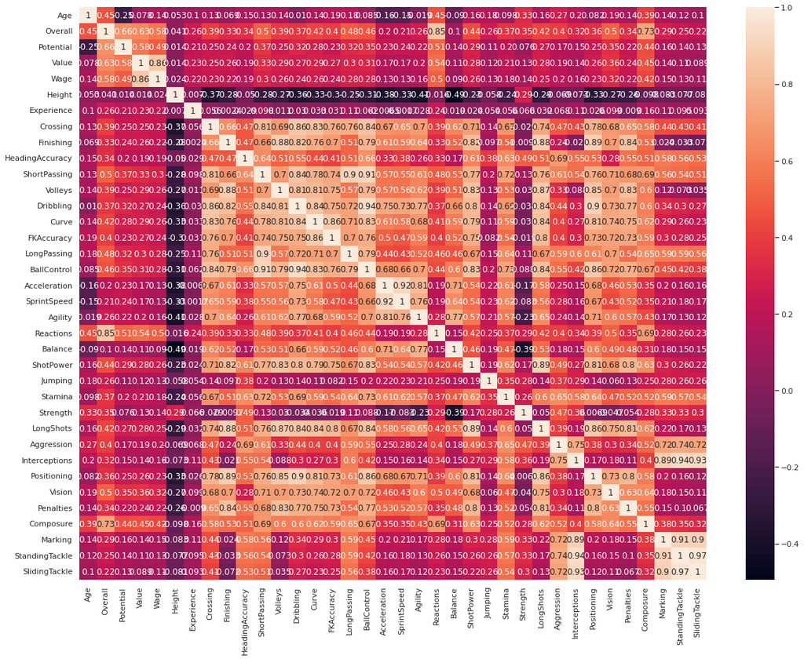

```python
import seaborn as sns
sns.set(rc = {'figure.figsize':(20,15)})
sns.heatmap(t.corr(),annot=True)
```

## Finding which different countries are player from

Since the game is impacted by the whole strength of the team. We are considering the team as whole instead of individual players in finding analysis

```python
from wordcloud import WordCloud, STOPWORDS, ImageColorGenerator
```

```python
import matplotlib.pyplot as plt
```

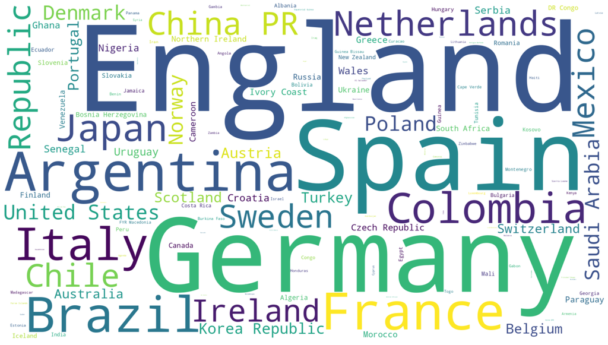

```python
plt.subplots(figsize=(25,15))
wordcloud = WordCloud(
                          background_color='white',
                          width=1920,
                          height=1080
                         ).generate(" ".join(df.Nationality))
plt.imshow(wordcloud, interpolation='bilinear')
plt.axis('off')
plt.savefig('graph.png')
plt.show()
```

```python
df.columns
```

```
Index(['Name', 'Age', 'Nationality', 'Overall', 'Potential', 'Club', 'Value',
       'Wage', 'Special', 'Preferred Foot', 'International Reputation',
       'Weak Foot', 'Skill Moves', 'Work Rate', 'Body Type', 'Real Face',
       'Position', 'Jersey Number', 'Height', 'Weight', 'LS', 'ST', 'RS', 'LW',
       'LF', 'CF', 'RF', 'RW', 'LAM', 'CAM', 'RAM', 'LM', 'LCM', 'CM', 'RCM',
       'RM', 'LWB', 'LDM', 'CDM', 'RDM', 'RWB', 'LB', 'LCB', 'CB', 'RCB', 'RB',
       'Crossing', 'Finishing', 'HeadingAccuracy', 'ShortPassing', 'Volleys',
       'Dribbling', 'Curve', 'FKAccuracy', 'LongPassing', 'BallControl',
       'Acceleration', 'SprintSpeed', 'Agility', 'Reactions', 'Balance',
       'ShotPower', 'Jumping', 'Stamina', 'Strength', 'LongShots',
       'Aggression', 'Interceptions', 'Positioning', 'Vision', 'Penalties',
       'Composure', 'Marking', 'StandingTackle', 'SlidingTackle', 'GKDiving',
       'GKHandling', 'GKKicking', 'GKPositioning', 'GKReflexes',
       'Release Clause', 'Experience'],
      dtype='object')
```

```python
## Finding club with highest potential
nationality_df = df.groupby('Nationality').mean()
nationality_df
```

| Nationality | Age | Overall | Potential | Value | Wage | Special | International Reputation | Weak Foot | Skill Moves | Jersey Number | ... | Marking | StandingTackle | SlidingTackle | GKDiving | GKHandling | GKKicking | GKPositioning | GKReflexes | Release Clause | Experience |
| --- | --- | --- | --- | --- | --- | --- | --- | --- | --- | --- | --- | --- | --- | --- | --- | --- | --- | --- | --- | --- | --- |
| Afghanistan | 22.500000 | 61.000000 | 67.750000 | 3.425000e+05 | 1250.000000 | 1613.250000 | 1.000000 | 2.750000 | 2.500000 | 16.250000 | ... | 45.750000 | 48.250000 | 47.750000 | 13.000000 | 12.000000 | 9.250000 | 8.500000 | 9.250000 | 6.172500e+05 | 2.500000 |
| Albania | 24.025000 | 65.925000 | 71.700000 | 1.920250e+06 | 7100.000000 | 1643.475000 | 1.102564 | 3.102564 | 2.487179 | 20.461538 | ... | 51.307692 | 51.282051 | 48.384615 | 13.615385 | 13.358974 | 13.589744 | 13.282051 | 14.384615 | 3.621784e+06 | 3.756757 |
| Algeria | 27.050000 | 70.633333 | 72.983333 | 4.670917e+06 | 18083.333333 | 1723.716667 | 1.300000 | 3.133333 | 2.816667 | 19.950000 | ... | 47.800000 | 49.733333 | 45.900000 | 15.866667 | 15.033333 | 14.800000 | 15.183333 | 15.800000 | 8.768946e+06 | 3.482143 |
| Andorra | 28.000000 | 62.000000 | 64.000000 | 2.900000e+05 | 1000.000000 | 1517.000000 | 1.000000 | 3.000000 | 2.000000 | 17.000000 | ... | 54.000000 | 56.000000 | 67.000000 | 9.000000 | 7.000000 | 12.000000 | 8.000000 | 6.000000 | 3.840000e+05 | 2.000000 |
| Angola | 25.866667 | 67.600000 | 71.533333 | 2.018333e+06 | 7666.666667 | 1707.000000 | 1.133333 | 3.066667 | 2.933333 | 27.933333 | ... | 47.733333 | 42.133333 | 39.400000 | 11.266667 | 9.733333 | 9.800000 | 10.200000 | 10.200000 | 3.475846e+06 | 2.615385 |
| ... | ... | ... | ... | ... | ... | ... | ... | ... | ... | ... | ... | ... | ... | ... | ... | ... | ... | ... | ... | ... | ... |
| Uzbekistan | 29.500000 | 67.500000 | 67.500000 | 3.100000e+06 | 9000.000000 | 1813.500000 | 1.000000 | 3.500000 | 2.500000 | 16.500000 | ... | 57.500000 | 69.000000 | 66.000000 | 13.500000 | 13.000000 | 12.500000 | 10.500000 | 12.500000 | 6.725000e+06 | 3.500000 |
| Venezuela | 24.313433 | 67.268657 | 73.149254 | 2.498333e+06 | 6916.666667 | 1611.462687 | 1.106061 | 3.060606 | 2.530303 | 16.984848 | ... | 44.893939 | 43.303030 | 42.287879 | 13.833333 | 13.287879 | 13.500000 | 14.363636 | 14.287879 | 4.093058e+06 | 2.942308 |
| Wales | 24.736434 | 64.139535 | 69.968992 | 1.769258e+06 | 12187.500000 | 1547.666667 | 1.093023 | 2.875969 | 2.248062 | 18.077519 | ... | 48.224806 | 49.341085 | 46.961240 | 16.325581 | 15.937984 | 16.054264 | 15.968992 | 15.875969 | 3.616793e+06 | 3.810345 |
| Zambia | 22.222222 | 65.222222 | 73.777778 | 1.129444e+06 | 3444.444444 | 1624.666667 | 1.000000 | 2.777778 | 2.333333 | 17.555556 | ... | 34.888889 | 36.222222 | 34.444444 | 10.888889 | 9.111111 | 9.555556 | 10.444444 | 11.111111 | 2.174000e+06 | 3.444444 |
| Zimbabwe | 26.846154 | 69.769231 | 72.461538 | 2.780769e+06 | 6846.153846 | 1768.692308 | 1.000000 | 3.076923 | 2.692308 | 23.692308 | ... | 51.000000 | 56.461538 | 55.000000 | 12.230769 | 9.538462 | 10.384615 | 10.846154 | 9.692308 | 5.319385e+06 | 4.000000 |

164 rows × 47 columns

```python
nationality_df.columns
```

```
Index(['Age', 'Overall', 'Potential', 'Value', 'Wage', 'Special',
       'International Reputation', 'Weak Foot', 'Skill Moves', 'Jersey Number',
       'Height', 'Crossing', 'Finishing', 'HeadingAccuracy', 'ShortPassing',
       'Volleys', 'Dribbling', 'Curve', 'FKAccuracy', 'LongPassing',
       'BallControl', 'Acceleration', 'SprintSpeed', 'Agility', 'Reactions',
       'Balance', 'ShotPower', 'Jumping', 'Stamina', 'Strength', 'LongShots',
       'Aggression', 'Interceptions', 'Positioning', 'Vision', 'Penalties',
       'Composure', 'Marking', 'StandingTackle', 'SlidingTackle', 'GKDiving',
       'GKHandling', 'GKKicking', 'GKPositioning', 'GKReflexes',
       'Release Clause', 'Experience'],
      dtype='object')
```

## Country wise age of players

Minimum age is of Indonesia and maximum is of Oman

```python
fig = px.histogram(y=nationality_df['Age'],x=nationality_df.index)
fig.update_layout(
    margin=dict(l=70, r=70, t=50, b=50),
)
```

[interactive chart not shown]

### Finding the age of the famous teams i.e 'FC Barcelona','Chelsea','Juventus','Real Madrid'

```python
t = df[df['Club'].isin(['FC Barcelona','Chelsea','Juventus','Real Madrid'])]
t
```

|  | Name | Age | Nationality | Overall | Potential | Club | Value | Wage | Special | Preferred Foot | ... | Marking | StandingTackle | SlidingTackle | GKDiving | GKHandling | GKKicking | GKPositioning | GKReflexes | Release Clause | Experience |
| --- | --- | --- | --- | --- | --- | --- | --- | --- | --- | --- | --- | --- | --- | --- | --- | --- | --- | --- | --- | --- | --- |
| 0 | L. Messi | 31 | Argentina | 94 | 94 | FC Barcelona | 110500000.0 | 565000.0 | 2202 | Left | ... | 33.0 | 28.0 | 26.0 | 6.0 | 11.0 | 15.0 | 14.0 | 8.0 | 226500000.0 | 17.0 |
| 1 | Cristiano Ronaldo | 33 | Portugal | 94 | 94 | Juventus | 77000000.0 | 405000.0 | 2228 | Right | ... | 28.0 | 31.0 | 23.0 | 7.0 | 11.0 | 15.0 | 14.0 | 11.0 | 127100000.0 | 4.0 |
| 5 | E. Hazard | 27 | Belgium | 91 | 91 | Chelsea | 93000000.0 | 340000.0 | 2142 | Right | ... | 34.0 | 27.0 | 22.0 | 11.0 | 12.0 | 6.0 | 8.0 | 8.0 | 172100000.0 | 8.0 |
| 6 | L. Modrić | 32 | Croatia | 91 | 91 | Real Madrid | 67000000.0 | 420000.0 | 2280 | Right | ... | 60.0 | 76.0 | 73.0 | 13.0 | 9.0 | 7.0 | 14.0 | 9.0 | 137400000.0 | 8.0 |
| 7 | L. Suárez | 31 | Uruguay | 91 | 91 | FC Barcelona | 80000000.0 | 455000.0 | 2346 | Right | ... | 62.0 | 45.0 | 38.0 | 27.0 | 25.0 | 31.0 | 33.0 | 37.0 | 164000000.0 | 7.0 |
| ... | ... | ... | ... | ... | ... | ... | ... | ... | ... | ... | ... | ... | ... | ... | ... | ... | ... | ... | ... | ... | ... |
| 14603 | B. Gilmour | 17 | Scotland | 61 | 84 | Chelsea | 550000.0 | 7000.0 | 1613 | Right | ... | 41.0 | 45.0 | 47.0 | 9.0 | 7.0 | 9.0 | 13.0 | 12.0 | 1600000.0 | 3.0 |
| 14646 | M. Taylor-Crossdale | 18 | England | 61 | 79 | Chelsea | 525000.0 | 8000.0 | 1490 | Right | ... | 28.0 | 21.0 | 17.0 | 7.0 | 8.0 | 8.0 | 11.0 | 8.0 | 1300000.0 | 3.0 |
| 15322 | G. McEachran | 17 | England | 59 | 81 | Chelsea | 350000.0 | 6000.0 | 1516 | Left | ... | 38.0 | 55.0 | 52.0 | 8.0 | 14.0 | 7.0 | 10.0 | 5.0 | 998000.0 | 2.0 |
| 15846 | M. Guehi | 17 | England | 58 | 78 | Chelsea | 230000.0 | 4000.0 | 1329 | Right | ... | 60.0 | 60.0 | 59.0 | 8.0 | 9.0 | 11.0 | 12.0 | 12.0 | 656000.0 | 3.0 |
| 16806 | M. Bulka | 18 | Poland | 56 | 74 | Chelsea | 150000.0 | 2000.0 | 885 | Right | ... | 12.0 | 10.0 | 14.0 | 57.0 | 54.0 | 56.0 | 52.0 | 59.0 | 371000.0 | 3.0 |

124 rows × 82 columns

```python
t = t[t.Age.notna()]
```

```python
t = t[t.Club.notna()]
```

```python
x1 = t[t.Club == 'FC Barcelona'].Age
x2 = t[t.Club == 'Chelsea'].Age
x3 = t[t.Club == 'Juventus'].Age
x4 = t[t.Club == 'Real Madrid'].Age
```

```python
ff.create_distplot([x1,x2,x3,x4],['FC Barcelona','Chelsa','Juventus','Real Madrid'],curve_type='kde')
```

[interactive chart not shown]

Here we can see that the players age of FC Barcelona and Real Madrid are younder than Juventus and Chelsa

## Finding average experience of famous team

```python
t=t[t.Experience.notna()]
```

```python
x1 = t[t.Club == 'FC Barcelona'].Experience
x2 = t[t.Club == 'Chelsea'].Experience
x3 = t[t.Club == 'Juventus'].Experience
x4 = t[t.Club == 'Real Madrid'].Experience
```

```python
ff.create_distplot([x1,x2,x3,x4],['FC Barcelona','Chelsa','Juventus','Real Madrid'],curve_type='kde')
```

[interactive chart not shown]

Juventus and FC Barcelona have highly experienced players than Chelsa and Real Madrid

## Country wise wage of the players

```python
fig = px.histogram(y=nationality_df['Wage'],x=nationality_df.index)
fig.update_layout(
    margin=dict(l=70, r=70, t=50, b=50),
)
```

[interactive chart not shown]

```python
df[['Wage']].max()
```

```
Wage    565000.0
dtype: float64
```

```python
nationality_df.describe()
```

|  | Age | Overall | Potential | Value | Wage | Special | International Reputation | Weak Foot | Skill Moves | Jersey Number | ... | Marking | StandingTackle | SlidingTackle | GKDiving | GKHandling | GKKicking | GKPositioning | GKReflexes | Release Clause | Experience |
| --- | --- | --- | --- | --- | --- | --- | --- | --- | --- | --- | --- | --- | --- | --- | --- | --- | --- | --- | --- | --- | --- |
| count | 164.000000 | 164.000000 | 164.000000 | 1.630000e+02 | 163.000000 | 164.000000 | 164.000000 | 164.000000 | 164.000000 | 164.000000 | ... | 164.000000 | 164.000000 | 164.000000 | 164.000000 | 164.000000 | 164.000000 | 164.000000 | 164.000000 | 1.610000e+02 | 161.000000 |
| mean | 25.655131 | 66.339956 | 70.512076 | 2.105820e+06 | 8406.675037 | 1623.254088 | 1.086006 | 2.955090 | 2.438213 | 19.675407 | ... | 47.042268 | 47.526748 | 45.537179 | 14.643784 | 14.490284 | 14.142232 | 14.574680 | 14.625665 | 3.962327e+06 | 3.434426 |
| std | 2.308003 | 3.415552 | 3.294534 | 1.795392e+06 | 7703.938995 | 109.852662 | 0.135881 | 0.272660 | 0.393035 | 8.173769 | ... | 8.694722 | 10.002013 | 10.147116 | 6.861454 | 5.929798 | 6.628934 | 6.649262 | 7.130718 | 3.634324e+06 | 1.431850 |
| min | 17.000000 | 56.000000 | 61.000000 | 1.100000e+05 | 1000.000000 | 1249.000000 | 1.000000 | 2.000000 | 1.000000 | 2.000000 | ... | 18.000000 | 11.000000 | 11.000000 | 6.000000 | 5.000000 | 5.000000 | 5.500000 | 6.000000 | 1.650000e+05 | 0.000000 |
| 25% | 24.461989 | 63.704613 | 68.051136 | 8.158368e+05 | 3336.754643 | 1556.293155 | 1.000000 | 2.833333 | 2.217929 | 15.921875 | ... | 43.737500 | 43.649923 | 41.437666 | 10.666667 | 11.000000 | 10.300000 | 10.800000 | 10.666667 | 1.344250e+06 | 2.966667 |
| 50% | 25.238197 | 66.687500 | 71.000000 | 1.725000e+06 | 6916.666667 | 1632.271683 | 1.038665 | 3.000000 | 2.457118 | 18.902151 | ... | 47.362296 | 47.389552 | 45.337092 | 13.574359 | 13.547207 | 13.484375 | 14.000000 | 14.000000 | 3.104919e+06 | 3.441065 |
| 75% | 26.434089 | 68.894186 | 72.987500 | 2.899083e+06 | 11484.751360 | 1685.387097 | 1.133944 | 3.050089 | 2.645263 | 22.042793 | ... | 50.284144 | 50.922872 | 48.325799 | 17.016667 | 16.720582 | 16.470529 | 16.773019 | 16.931981 | 5.581600e+06 | 3.911765 |
| max | 36.000000 | 77.000000 | 80.500000 | 1.050000e+07 | 71000.000000 | 1931.000000 | 2.000000 | 4.000000 | 5.000000 | 77.000000 | ... | 71.000000 | 74.000000 | 70.000000 | 74.000000 | 58.000000 | 71.000000 | 73.000000 | 79.000000 | 2.195000e+07 | 17.000000 |

8 rows × 47 columns

```python
nationality_df.columns
```

```
Index(['Age', 'Overall', 'Potential', 'Value', 'Wage', 'Special',
       'International Reputation', 'Weak Foot', 'Skill Moves', 'Jersey Number',
       'Height', 'Crossing', 'Finishing', 'HeadingAccuracy', 'ShortPassing',
       'Volleys', 'Dribbling', 'Curve', 'FKAccuracy', 'LongPassing',
       'BallControl', 'Acceleration', 'SprintSpeed', 'Agility', 'Reactions',
       'Balance', 'ShotPower', 'Jumping', 'Stamina', 'Strength', 'LongShots',
       'Aggression', 'Interceptions', 'Positioning', 'Vision', 'Penalties',
       'Composure', 'Marking', 'StandingTackle', 'SlidingTackle', 'GKDiving',
       'GKHandling', 'GKKicking', 'GKPositioning', 'GKReflexes',
       'Release Clause', 'Experience'],
      dtype='object')
```

```python
nationality_df.iloc[:,-30:]
```

| Nationality | Curve | FKAccuracy | LongPassing | BallControl | Acceleration | SprintSpeed | Agility | Reactions | Balance | ShotPower | ... | Marking | StandingTackle | SlidingTackle | GKDiving | GKHandling | GKKicking | GKPositioning | GKReflexes | Release Clause | Experience |
| --- | --- | --- | --- | --- | --- | --- | --- | --- | --- | --- | --- | --- | --- | --- | --- | --- | --- | --- | --- | --- | --- |
| Afghanistan | 54.500000 | 48.250000 | 54.000000 | 60.250000 | 70.500000 | 68.000000 | 76.250000 | 55.750000 | 77.250000 | 53.750000 | ... | 45.750000 | 48.250000 | 47.750000 | 13.000000 | 12.000000 | 9.250000 | 8.500000 | 9.250000 | 6.172500e+05 | 2.500000 |
| Albania | 49.358974 | 46.358974 | 54.307692 | 60.897436 | 67.051282 | 67.846154 | 66.230769 | 60.358974 | 65.974359 | 57.743590 | ... | 51.307692 | 51.282051 | 48.384615 | 13.615385 | 13.358974 | 13.589744 | 13.282051 | 14.384615 | 3.621784e+06 | 3.756757 |
| Algeria | 56.150000 | 52.100000 | 59.600000 | 65.250000 | 65.733333 | 66.116667 | 66.866667 | 65.983333 | 65.816667 | 60.750000 | ... | 47.800000 | 49.733333 | 45.900000 | 15.866667 | 15.033333 | 14.800000 | 15.183333 | 15.800000 | 8.768946e+06 | 3.482143 |
| Andorra | 37.000000 | 29.000000 | 58.000000 | 54.000000 | 57.000000 | 71.000000 | 47.000000 | 56.000000 | 53.000000 | 58.000000 | ... | 54.000000 | 56.000000 | 67.000000 | 9.000000 | 7.000000 | 12.000000 | 8.000000 | 6.000000 | 3.840000e+05 | 2.000000 |
| Angola | 52.800000 | 47.000000 | 53.400000 | 65.733333 | 78.600000 | 78.800000 | 74.333333 | 62.466667 | 68.866667 | 65.600000 | ... | 47.733333 | 42.133333 | 39.400000 | 11.266667 | 9.733333 | 9.800000 | 10.200000 | 10.200000 | 3.475846e+06 | 2.615385 |
| ... | ... | ... | ... | ... | ... | ... | ... | ... | ... | ... | ... | ... | ... | ... | ... | ... | ... | ... | ... | ... | ... |
| Uzbekistan | 53.000000 | 54.000000 | 64.500000 | 70.500000 | 71.500000 | 64.000000 | 65.500000 | 69.000000 | 66.500000 | 71.500000 | ... | 57.500000 | 69.000000 | 66.000000 | 13.500000 | 13.000000 | 12.500000 | 10.500000 | 12.500000 | 6.725000e+06 | 3.500000 |
| Venezuela | 49.803030 | 44.151515 | 52.939394 | 60.742424 | 66.772727 | 66.833333 | 65.151515 | 62.136364 | 66.121212 | 59.681818 | ... | 44.893939 | 43.303030 | 42.287879 | 13.833333 | 13.287879 | 13.500000 | 14.363636 | 14.287879 | 4.093058e+06 | 2.942308 |
| Wales | 44.240310 | 38.713178 | 51.248062 | 55.813953 | 63.139535 | 62.891473 | 62.372093 | 58.441860 | 65.279070 | 50.186047 | ... | 48.224806 | 49.341085 | 46.961240 | 16.325581 | 15.937984 | 16.054264 | 15.968992 | 15.875969 | 3.616793e+06 | 3.810345 |
| Zambia | 48.555556 | 49.111111 | 47.666667 | 62.666667 | 75.888889 | 74.666667 | 67.000000 | 59.222222 | 68.444444 | 63.666667 | ... | 34.888889 | 36.222222 | 34.444444 | 10.888889 | 9.111111 | 9.555556 | 10.444444 | 11.111111 | 2.174000e+06 | 3.444444 |
| Zimbabwe | 50.307692 | 44.692308 | 59.538462 | 63.076923 | 77.692308 | 78.769231 | 71.461538 | 61.538462 | 70.461538 | 63.000000 | ... | 51.000000 | 56.461538 | 55.000000 | 12.230769 | 9.538462 | 10.384615 | 10.846154 | 9.692308 | 5.319385e+06 | 4.000000 |

164 rows × 30 columns

## Finding the nation wise performance

By Considering the values of 'HeadingAccuracy', 'FKAccuracy','ShotPower', 'Jumping', 'Stamina', 'Strength'

```python
perf_nat = pd.DataFrame(nationality_df[['HeadingAccuracy', 'FKAccuracy','ShotPower', 'Jumping', 'Stamina', 'Strength']])
```

```python
fig = px.imshow(perf_nat.corr(),text_auto=True)
fig
```

[interactive chart not shown]

```python
perf_nat
```

| Nationality | HeadingAccuracy | FKAccuracy | ShotPower | Jumping | Stamina | Strength |
| --- | --- | --- | --- | --- | --- | --- |
| Afghanistan | 42.000000 | 48.250000 | 53.750000 | 58.500000 | 70.000000 | 55.250000 |
| Albania | 51.282051 | 46.358974 | 57.743590 | 63.974359 | 66.358974 | 63.487179 |
| Algeria | 55.716667 | 52.100000 | 60.750000 | 66.866667 | 65.633333 | 66.900000 |
| Andorra | 70.000000 | 29.000000 | 58.000000 | 73.000000 | 64.000000 | 75.000000 |
| Angola | 57.866667 | 47.000000 | 65.600000 | 71.533333 | 63.000000 | 70.066667 |
| ... | ... | ... | ... | ... | ... | ... |
| Uzbekistan | 53.500000 | 54.000000 | 71.500000 | 70.500000 | 70.000000 | 69.000000 |
| Venezuela | 54.515152 | 44.151515 | 59.681818 | 66.348485 | 62.545455 | 64.318182 |
| Wales | 51.364341 | 38.713178 | 50.186047 | 66.806202 | 63.155039 | 65.240310 |
| Zambia | 55.333333 | 49.111111 | 63.666667 | 71.000000 | 63.000000 | 64.444444 |
| Zimbabwe | 62.923077 | 44.692308 | 63.000000 | 72.769231 | 71.769231 | 69.692308 |

164 rows × 6 columns

```python
perf_nat['Sum'] = perf_nat.sum(axis=1)
```

```python
t = perf_nat.sort_values(by='Sum')
t
```

| Nationality | HeadingAccuracy | FKAccuracy | ShotPower | Jumping | Stamina | Strength | Sum |
| --- | --- | --- | --- | --- | --- | --- | --- |
| Oman | 16.000000 | 11.000000 | 22.000000 | 74.0 | 41.000000 | 64.000000 | 228.0 |
| Malta | 38.000000 | 39.000000 | 45.000000 | 59.0 | 52.000000 | 38.000000 | 271.0 |
| Indonesia | 40.000000 | 44.000000 | 47.000000 | 55.0 | 44.000000 | 43.000000 | 273.0 |
| Philippines | 30.500000 | 23.500000 | 43.500000 | 60.5 | 42.500000 | 75.500000 | 276.0 |
| Guatemala | 45.666667 | 29.000000 | 39.666667 | 63.0 | 54.333333 | 67.333333 | 299.0 |
| ... | ... | ... | ... | ... | ... | ... | ... |
| Nicaragua | 63.000000 | 59.000000 | 65.000000 | 74.0 | 70.000000 | 77.000000 | 408.0 |
| Central African Rep. | 71.000000 | 47.666667 | 58.000000 | 73.0 | 73.333333 | 87.000000 | 410.0 |
| Dominican Republic | 66.500000 | 63.500000 | 75.500000 | 69.5 | 71.500000 | 65.500000 | 412.0 |
| Fiji | 64.000000 | 63.000000 | 72.000000 | 78.0 | 71.000000 | 72.000000 | 420.0 |
| São Tomé & Príncipe | 67.000000 | 73.000000 | 81.000000 | 61.0 | 68.000000 | 75.000000 | 425.0 |

164 rows × 7 columns

```python
t.iplot(kind='bar',y='Sum')
```

[interactive chart not shown]

### country wise good goal keepers

```python
nationality_df = df.groupby('Nationality').mean()
nationality_df
```

| Nationality | Age | Overall | Potential | Value | Wage | Special | International Reputation | Weak Foot | Skill Moves | Jersey Number | ... | Marking | StandingTackle | SlidingTackle | GKDiving | GKHandling | GKKicking | GKPositioning | GKReflexes | Release Clause | Experience |
| --- | --- | --- | --- | --- | --- | --- | --- | --- | --- | --- | --- | --- | --- | --- | --- | --- | --- | --- | --- | --- | --- |
| Afghanistan | 22.500000 | 61.000000 | 67.750000 | 3.425000e+05 | 1250.000000 | 1613.250000 | 1.000000 | 2.750000 | 2.500000 | 16.250000 | ... | 45.750000 | 48.250000 | 47.750000 | 13.000000 | 12.000000 | 9.250000 | 8.500000 | 9.250000 | 6.172500e+05 | 2.500000 |
| Albania | 24.025000 | 65.925000 | 71.700000 | 1.920250e+06 | 7100.000000 | 1643.475000 | 1.102564 | 3.102564 | 2.487179 | 20.461538 | ... | 51.307692 | 51.282051 | 48.384615 | 13.615385 | 13.358974 | 13.589744 | 13.282051 | 14.384615 | 3.621784e+06 | 3.756757 |
| Algeria | 27.050000 | 70.633333 | 72.983333 | 4.670917e+06 | 18083.333333 | 1723.716667 | 1.300000 | 3.133333 | 2.816667 | 19.950000 | ... | 47.800000 | 49.733333 | 45.900000 | 15.866667 | 15.033333 | 14.800000 | 15.183333 | 15.800000 | 8.768946e+06 | 3.482143 |
| Andorra | 28.000000 | 62.000000 | 64.000000 | 2.900000e+05 | 1000.000000 | 1517.000000 | 1.000000 | 3.000000 | 2.000000 | 17.000000 | ... | 54.000000 | 56.000000 | 67.000000 | 9.000000 | 7.000000 | 12.000000 | 8.000000 | 6.000000 | 3.840000e+05 | 2.000000 |
| Angola | 25.866667 | 67.600000 | 71.533333 | 2.018333e+06 | 7666.666667 | 1707.000000 | 1.133333 | 3.066667 | 2.933333 | 27.933333 | ... | 47.733333 | 42.133333 | 39.400000 | 11.266667 | 9.733333 | 9.800000 | 10.200000 | 10.200000 | 3.475846e+06 | 2.615385 |
| ... | ... | ... | ... | ... | ... | ... | ... | ... | ... | ... | ... | ... | ... | ... | ... | ... | ... | ... | ... | ... | ... |
| Uzbekistan | 29.500000 | 67.500000 | 67.500000 | 3.100000e+06 | 9000.000000 | 1813.500000 | 1.000000 | 3.500000 | 2.500000 | 16.500000 | ... | 57.500000 | 69.000000 | 66.000000 | 13.500000 | 13.000000 | 12.500000 | 10.500000 | 12.500000 | 6.725000e+06 | 3.500000 |
| Venezuela | 24.313433 | 67.268657 | 73.149254 | 2.498333e+06 | 6916.666667 | 1611.462687 | 1.106061 | 3.060606 | 2.530303 | 16.984848 | ... | 44.893939 | 43.303030 | 42.287879 | 13.833333 | 13.287879 | 13.500000 | 14.363636 | 14.287879 | 4.093058e+06 | 2.942308 |
| Wales | 24.736434 | 64.139535 | 69.968992 | 1.769258e+06 | 12187.500000 | 1547.666667 | 1.093023 | 2.875969 | 2.248062 | 18.077519 | ... | 48.224806 | 49.341085 | 46.961240 | 16.325581 | 15.937984 | 16.054264 | 15.968992 | 15.875969 | 3.616793e+06 | 3.810345 |
| Zambia | 22.222222 | 65.222222 | 73.777778 | 1.129444e+06 | 3444.444444 | 1624.666667 | 1.000000 | 2.777778 | 2.333333 | 17.555556 | ... | 34.888889 | 36.222222 | 34.444444 | 10.888889 | 9.111111 | 9.555556 | 10.444444 | 11.111111 | 2.174000e+06 | 3.444444 |
| Zimbabwe | 26.846154 | 69.769231 | 72.461538 | 2.780769e+06 | 6846.153846 | 1768.692308 | 1.000000 | 3.076923 | 2.692308 | 23.692308 | ... | 51.000000 | 56.461538 | 55.000000 | 12.230769 | 9.538462 | 10.384615 | 10.846154 | 9.692308 | 5.319385e+06 | 4.000000 |

164 rows × 47 columns

```python
nationality_df_gk = nationality_df.iloc[::,-7:-2]
```

```python
nationality_df_gk.sum(axis=1).sort_values().iplot(kind='bar')
```

[interactive chart not shown]

- Goal keeping of Oman is 7 times better than Belize

## Finding average release clause of different clubs

```python
df.groupby('Club').mean()['Release Clause'].sort_values().iplot(kind='bar')
```

[interactive chart not shown]

Release clause of FC Barcelona and Real Madrid is at highest

## Finding best club based on Overall Performance value and potential

```python
df.groupby('Club').mean()[['Overall','Potential']].sum(axis=1).sort_values().iplot(kind='bar')
```

[interactive chart not shown]

FC barcelona and Real Madrid are best

### Finding Top performing country based on Overall Performance value and potential

```python
df.groupby('Nationality').mean()[['Overall','Potential']].sum(axis=1).sort_values().iplot(kind='bar')
```

[interactive chart not shown]

UAE and Dominica Republic are best

### Comparing performance based on preferred leg

```python
t = df[['Name','Overall','Potential','Preferred Foot']].copy()
```

```python
t.dropna(inplace=True)
```

```python
px.scatter(data_frame=t,x='Overall',y='Potential',color='Preferred Foot',trendline="lowess")
```

[interactive chart not shown]

```python
!pip install statsmodels
```

## Relation between performance and wage

```python
px.scatter(x='Overall',y='Wage',data_frame=df,log_x=True,trendline_options=dict(log_x=True),trendline='ols')
```

[interactive chart not shown]

## Relation between potential and talent

```python
df.columns
```

```
Index(['Name', 'Age', 'Nationality', 'Overall', 'Potential', 'Club', 'Value',
       'Wage', 'Special', 'Preferred Foot', 'International Reputation',
       'Weak Foot', 'Skill Moves', 'Work Rate', 'Body Type', 'Real Face',
       'Position', 'Jersey Number', 'Height', 'Weight', 'LS', 'ST', 'RS', 'LW',
       'LF', 'CF', 'RF', 'RW', 'LAM', 'CAM', 'RAM', 'LM', 'LCM', 'CM', 'RCM',
       'RM', 'LWB', 'LDM', 'CDM', 'RDM', 'RWB', 'LB', 'LCB', 'CB', 'RCB', 'RB',
       'Crossing', 'Finishing', 'HeadingAccuracy', 'ShortPassing', 'Volleys',
       'Dribbling', 'Curve', 'FKAccuracy', 'LongPassing', 'BallControl',
       'Acceleration', 'SprintSpeed', 'Agility', 'Reactions', 'Balance',
       'ShotPower', 'Jumping', 'Stamina', 'Strength', 'LongShots',
       'Aggression', 'Interceptions', 'Positioning', 'Vision', 'Penalties',
       'Composure', 'Marking', 'StandingTackle', 'SlidingTackle', 'GKDiving',
       'GKHandling', 'GKKicking', 'GKPositioning', 'GKReflexes',
       'Release Clause', 'Experience'],
      dtype='object')
```

```python
df.groupby('Age').mean()[['Overall','Potential']].iplot()
```

[interactive chart not shown]

After the age of 30 the Performance and Potential intersect

## Polar plot of the performance

```python
# functions to get the rounded values from different columns
def defending(data):
    return int(round((data[['Marking', 'StandingTackle',
                               'SlidingTackle']].mean()).mean()))

def general(data):
    return int(round((data[['HeadingAccuracy', 'Dribbling', 'Curve',
                               'BallControl']].mean()).mean()))

def mental(data):
    return int(round((data[['Aggression', 'Interceptions', 'Positioning',
                               'Vision','Composure']].mean()).mean()))

def passing(data):
    return int(round((data[['Crossing', 'ShortPassing',
                               'LongPassing']].mean()).mean()))

def mobility(data):
    return int(round((data[['Acceleration', 'SprintSpeed',
                               'Agility','Reactions']].mean()).mean()))
def power(data):
    return int(round((data[['Balance', 'Jumping', 'Stamina',
                               'Strength']].mean()).mean()))

def rating(data):
    return int(round((data[['Potential', 'Overall']].mean()).mean()))

def shooting(data):
    return int(round((data[['Finishing', 'Volleys', 'FKAccuracy',
                               'ShotPower','LongShots', 'Penalties']].mean()).mean()))
```

```python
df.fillna(0, inplace = True) # Filling the remaining  missing values with zero
df.head(20)
```

|  | Name | Age | Nationality | Overall | Potential | Club | Value | Wage | Special | Preferred Foot | ... | Marking | StandingTackle | SlidingTackle | GKDiving | GKHandling | GKKicking | GKPositioning | GKReflexes | Release Clause | Experience |
| --- | --- | --- | --- | --- | --- | --- | --- | --- | --- | --- | --- | --- | --- | --- | --- | --- | --- | --- | --- | --- | --- |
| 0 | L. Messi | 31 | Argentina | 94 | 94 | FC Barcelona | 110500000.0 | 565000.0 | 2202 | Left | ... | 33.0 | 28.0 | 26.0 | 6.0 | 11.0 | 15.0 | 14.0 | 8.0 | 226500000.0 | 17.0 |
| 1 | Cristiano Ronaldo | 33 | Portugal | 94 | 94 | Juventus | 77000000.0 | 405000.0 | 2228 | Right | ... | 28.0 | 31.0 | 23.0 | 7.0 | 11.0 | 15.0 | 14.0 | 11.0 | 127100000.0 | 4.0 |
| 2 | Neymar Jr | 26 | Brazil | 92 | 93 | Paris Saint-Germain | 118500000.0 | 290000.0 | 2143 | Right | ... | 27.0 | 24.0 | 33.0 | 9.0 | 9.0 | 15.0 | 15.0 | 11.0 | 228100000.0 | 5.0 |
| 3 | De Gea | 27 | Spain | 91 | 93 | Manchester United | 72000000.0 | 260000.0 | 1471 | Right | ... | 15.0 | 21.0 | 13.0 | 90.0 | 85.0 | 87.0 | 88.0 | 94.0 | 138600000.0 | 9.0 |
| 4 | K. De Bruyne | 27 | Belgium | 91 | 92 | Manchester City | 102000000.0 | 355000.0 | 2281 | Right | ... | 68.0 | 58.0 | 51.0 | 15.0 | 13.0 | 5.0 | 10.0 | 13.0 | 196400000.0 | 8.0 |
| 5 | E. Hazard | 27 | Belgium | 91 | 91 | Chelsea | 93000000.0 | 340000.0 | 2142 | Right | ... | 34.0 | 27.0 | 22.0 | 11.0 | 12.0 | 6.0 | 8.0 | 8.0 | 172100000.0 | 8.0 |
| 6 | L. Modrić | 32 | Croatia | 91 | 91 | Real Madrid | 67000000.0 | 420000.0 | 2280 | Right | ... | 60.0 | 76.0 | 73.0 | 13.0 | 9.0 | 7.0 | 14.0 | 9.0 | 137400000.0 | 8.0 |
| 7 | L. Suárez | 31 | Uruguay | 91 | 91 | FC Barcelona | 80000000.0 | 455000.0 | 2346 | Right | ... | 62.0 | 45.0 | 38.0 | 27.0 | 25.0 | 31.0 | 33.0 | 37.0 | 164000000.0 | 7.0 |
| 8 | Sergio Ramos | 32 | Spain | 91 | 91 | Real Madrid | 51000000.0 | 380000.0 | 2201 | Right | ... | 87.0 | 92.0 | 91.0 | 11.0 | 8.0 | 9.0 | 7.0 | 11.0 | 104600000.0 | 15.0 |
| 9 | J. Oblak | 25 | Slovenia | 90 | 93 | Atlético Madrid | 68000000.0 | 94000.0 | 1331 | Right | ... | 27.0 | 12.0 | 18.0 | 86.0 | 92.0 | 78.0 | 88.0 | 89.0 | 144500000.0 | 7.0 |
| 10 | R. Lewandowski | 29 | Poland | 90 | 90 | FC Bayern München | 77000000.0 | 205000.0 | 2152 | Right | ... | 34.0 | 42.0 | 19.0 | 15.0 | 6.0 | 12.0 | 8.0 | 10.0 | 127100000.0 | 7.0 |
| 11 | T. Kroos | 28 | Germany | 90 | 90 | Real Madrid | 76500000.0 | 355000.0 | 2190 | Right | ... | 72.0 | 79.0 | 69.0 | 10.0 | 11.0 | 13.0 | 7.0 | 10.0 | 156800000.0 | 8.0 |
| 12 | D. Godín | 32 | Uruguay | 90 | 90 | Atlético Madrid | 44000000.0 | 125000.0 | 1946 | Right | ... | 90.0 | 89.0 | 89.0 | 6.0 | 8.0 | 15.0 | 5.0 | 15.0 | 90200000.0 | 9.0 |
| 13 | David Silva | 32 | Spain | 90 | 90 | Manchester City | 60000000.0 | 285000.0 | 2115 | Left | ... | 59.0 | 53.0 | 29.0 | 6.0 | 15.0 | 7.0 | 6.0 | 12.0 | 111000000.0 | 10.0 |
| 14 | N. Kanté | 27 | France | 89 | 90 | Chelsea | 63000000.0 | 225000.0 | 2189 | Right | ... | 90.0 | 91.0 | 85.0 | 15.0 | 12.0 | 10.0 | 7.0 | 10.0 | 121300000.0 | 7.0 |
| 15 | P. Dybala | 24 | Argentina | 89 | 94 | Juventus | 89000000.0 | 205000.0 | 2092 | Left | ... | 23.0 | 20.0 | 20.0 | 5.0 | 4.0 | 4.0 | 5.0 | 8.0 | 153500000.0 | 7.0 |
| 16 | H. Kane | 24 | England | 89 | 91 | Tottenham Hotspur | 83500000.0 | 205000.0 | 2165 | Right | ... | 56.0 | 36.0 | 38.0 | 8.0 | 10.0 | 11.0 | 14.0 | 11.0 | 160700000.0 | 14.0 |
| 17 | A. Griezmann | 27 | France | 89 | 90 | Atlético Madrid | 78000000.0 | 145000.0 | 2246 | Left | ... | 59.0 | 47.0 | 48.0 | 14.0 | 8.0 | 14.0 | 13.0 | 14.0 | 165800000.0 | 9.0 |
| 18 | M. ter Stegen | 26 | Germany | 89 | 92 | FC Barcelona | 58000000.0 | 240000.0 | 1328 | Right | ... | 25.0 | 13.0 | 10.0 | 87.0 | 85.0 | 88.0 | 85.0 | 90.0 | 123300000.0 | 8.0 |
| 19 | T. Courtois | 26 | Belgium | 89 | 90 | Real Madrid | 53500000.0 | 240000.0 | 1311 | Left | ... | 20.0 | 18.0 | 16.0 | 85.0 | 91.0 | 72.0 | 86.0 | 88.0 | 113700000.0 | 6.0 |

20 rows × 82 columns

```python
df['Defending'] = df.apply(defending, axis = 1)
df['General'] = df.apply(general, axis = 1)
df['Mental'] = df.apply(mental, axis = 1)
df['Passing'] = df.apply(passing, axis = 1)
df['Mobility'] = df.apply(mobility, axis = 1)
df['Power'] = df.apply(power, axis = 1)
df['Rating'] = df.apply(rating, axis = 1)
df['Shooting'] = df.apply(shooting, axis = 1)
```

```python
df.iloc[0,-8::]
```

```
Defending    29
General      89
Mental       71
Passing      87
Mobility     91
Power        74
Rating       94
Shooting     88
Name: 0, dtype: object
```

```python
df.columns
```

```
Index(['Name', 'Age', 'Nationality', 'Overall', 'Potential', 'Club', 'Value',
       'Wage', 'Special', 'Preferred Foot', 'International Reputation',
       'Weak Foot', 'Skill Moves', 'Work Rate', 'Body Type', 'Real Face',
       'Position', 'Jersey Number', 'Height', 'Weight', 'LS', 'ST', 'RS', 'LW',
       'LF', 'CF', 'RF', 'RW', 'LAM', 'CAM', 'RAM', 'LM', 'LCM', 'CM', 'RCM',
       'RM', 'LWB', 'LDM', 'CDM', 'RDM', 'RWB', 'LB', 'LCB', 'CB', 'RCB', 'RB',
       'Crossing', 'Finishing', 'HeadingAccuracy', 'ShortPassing', 'Volleys',
       'Dribbling', 'Curve', 'FKAccuracy', 'LongPassing', 'BallControl',
       'Acceleration', 'SprintSpeed', 'Agility', 'Reactions', 'Balance',
       'ShotPower', 'Jumping', 'Stamina', 'Strength', 'LongShots',
       'Aggression', 'Interceptions', 'Positioning', 'Vision', 'Penalties',
       'Composure', 'Marking', 'StandingTackle', 'SlidingTackle', 'GKDiving',
       'GKHandling', 'GKKicking', 'GKPositioning', 'GKReflexes',
       'Release Clause', 'Experience', 'Defending', 'General', 'Mental',
       'Passing', 'Mobility', 'Power', 'Rating', 'Shooting'],
      dtype='object')
```

```python
fig = px.line_polar( r=df.iloc[0,-8::], theta=df.columns[-8::], line_close=True,title=df.iloc[0,0])
fig.update_traces(fill='toself')
fig.show()
```

[interactive chart not shown]

```python
fig = px.line_polar( r=df.iloc[1,-8::], theta=df.columns[-8::], line_close=True,title=df.iloc[1,0])
fig.update_traces(fill='toself')
fig.show()
```

[interactive chart not shown]

```python
fig = px.line_polar( r=df.iloc[2,-8::], theta=df.columns[-8::], line_close=True,title=df.iloc[2,0])
fig.update_traces(fill='toself')
fig.show()
```

[interactive chart not shown]

## Finding bargain based on Kmeans clustering i.e person with closest performance and different

```python
from sklearn.cluster import KMeans
```

```python
X = df[['Overall','Potential','Name','Release Clause']]
```

```python
kmeans = KMeans(n_clusters=15, random_state=0).fit(X.iloc[::,0:2])
```

```python
set(kmeans.labels_)
```

```
{0, 1, 2, 3, 4, 5, 6, 7, 8, 9, 10, 11, 12, 13, 14}
```

Now finding the lowest Release clause

```python
kmeans.labels_
```

```
array([9, 9, 9, ..., 8, 8, 8], dtype=int32)
```

```python
X['Cluster_id'] = kmeans.labels_
```

```python
temp = X[X['Cluster_id'].sort_values().isin([9])].sort_values(by='Release Clause')
temp[temp['Release Clause'] != 0.0]
```

|  | Overall | Potential | Name | Release Clause | Cluster_id |
| --- | --- | --- | --- | --- | --- |
| 318 | 82 | 82 | Casillas | 3000000.0 | 9 |
| 317 | 82 | 82 | P. Čech | 5700000.0 | 9 |
| 152 | 84 | 84 | A. Barzagli | 6900000.0 | 9 |
| 41 | 88 | 88 | G. Buffon | 7400000.0 | 9 |
| 314 | 82 | 82 | Dani Alves | 8900000.0 | 9 |
| ... | ... | ... | ... | ... | ... |
| 25 | 88 | 95 | K. Mbappé | 166100000.0 | 9 |
| 5 | 91 | 91 | E. Hazard | 172100000.0 | 9 |
| 4 | 91 | 92 | K. De Bruyne | 196400000.0 | 9 |
| 0 | 94 | 94 | L. Messi | 226500000.0 | 9 |
| 2 | 92 | 93 | Neymar Jr | 228100000.0 | 9 |

418 rows × 5 columns